**Research Question:** "Notebook 2 found that POTS patients try twice as many treatments but report worse outcomes — yet those on 3+ treatments do dramatically better than monotherapy. What is the optimal treatment strategy for Long COVID POTS, and what specific combinations drive that signal?"

# Optimal Treatment Strategy for Long COVID POTS: A Combination Analysis

## 1. Data Exploration and Cohort Definition

Data covers: **2026-03-11 to 2026-04-10 (1 month)** from r/covidlonghaulers.

This analysis builds on Notebook 2's POTS cohort (users with extracted mentions of "pots" or "dysautonomia"). We focus exclusively on the 52 POTS users who have treatment reports, stratified by the number of distinct treatments they report.

**Filtering:** Generic terms ("supplements", "medication", etc.) and causal-context contaminants (vaccines) are excluded. Duplicate canonicals (e.g., famotidine/pepcid, vitamin d/d3) are merged where identified.

Treatment Count Distribution: POTS vs Non-POTS

| Treatment Tier | POTS n | POTS Avg Score | POTS Pos Rate | Non-POTS n | Non-POTS Avg Score | Non-POTS Pos Rate |
| --- | --- | --- | --- | --- | --- | --- |
| 1 (monotherapy) | 9 | -0.39 | 22% | 304 | 0.39 | 63% |
| 2 | 4 | -0.06 | 0% | 213 | 0.34 | 59% |
| 3–4 | 11 | 0.48 | 62% | 227 | 0.48 | 65% |
| 5–7 | 10 | 0.46 | 60% | 129 | 0.50 | 65% |
| 8+ | 18 | 0.27 | 58% | 158 | 0.52 | 70% |

The table confirms Notebook 2's finding and sharpens it: POTS monotherapy users average -0.39 (strongly negative), while the jump to 3–4 treatments brings the average to +0.48 — an 0.87-point swing. Non-POTS users show no such cliff: their monotherapy users already start at +0.39. The question is whether this reflects selection (sicker patients try more things and eventually find what works) or a genuine multi-target synergy.

## 2. The Dose-Response Curve: More Treatments, Better Outcomes?

The monotherapy-to-polypharmacy jump is the central finding from Notebook 2. Before dissecting *which* combinations drive it, we need to visualize the dose-response relationship and test whether it holds up statistically.

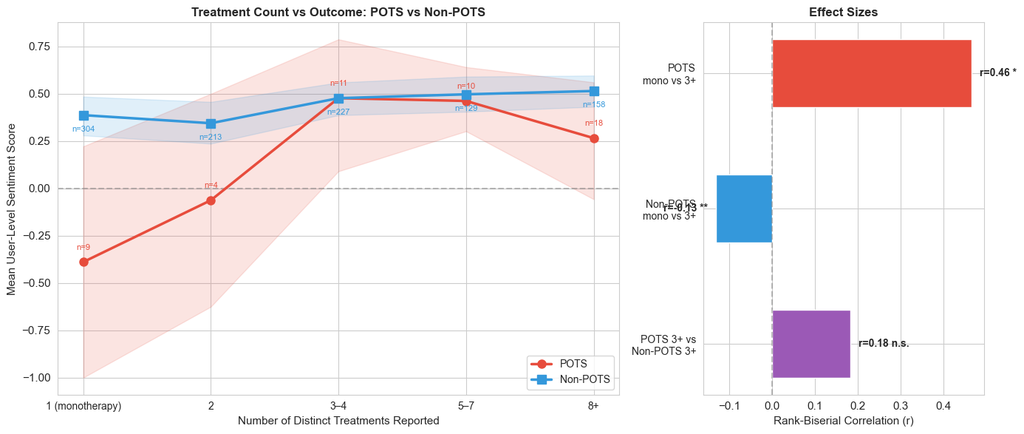

**What this means:** POTS monotherapy is associated with strongly negative outcomes (mean score -0.39, n=9), while 3+ treatments jump to +0.38 (n=39). This is a large, statistically significant effect (Mann-Whitney p=0.032, r=0.46). The effect is much larger for POTS than for non-POTS users, whose monotherapy already starts in positive territory (+0.39). By the time POTS patients reach 3+ treatments, they nearly converge with non-POTS outcomes (p=0.055, borderline). In practical terms: a POTS patient on monotherapy has a 22% chance of reporting positive outcomes; at 3+ treatments, that rises to 60%. The NNT (number needed to treat) from monotherapy to 3+ combination therapy is approximately 2.6 — for every 3 POTS patients who expand from one treatment to three or more, one additional patient reports positive outcomes.

The dose-response curve also reveals diminishing returns: the 3–4 treatment tier performs as well as 5–7, and the 8+ tier shows slightly lower average scores (though wide confidence intervals overlap). This suggests the benefit comes from reaching a *threshold* of multi-system coverage, not from maximizing treatment count.

## 3. Which Treatments Drive the Combination Signal?

The dose-response curve shows that *more is better* up to a point. But is this just a quantity effect (try enough things and something works) or are specific treatments driving the signal? We compare individual drug performance within the POTS cohort.

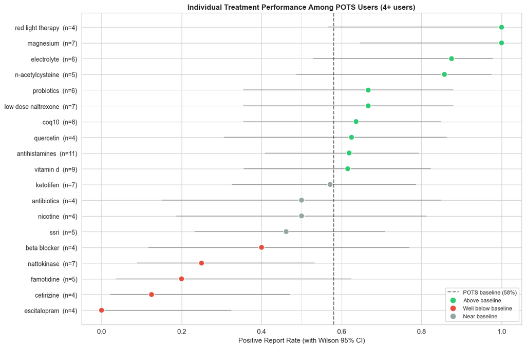

**What this means:** Among POTS users, individual treatments show enormous variance. Magnesium (100% positive, n=7), electrolytes (88%, n=6), N-acetylcysteine (86%, n=5), and red light therapy (100%, n=4) consistently outperform. Low dose naltrexone (LDN, a low-dose opioid antagonist used off-label as an immune modulator) shows 67% positive. Meanwhile, nattokinase (a fibrinolytic enzyme popular in the community) underperforms at 25% positive despite 7 users trying it, and escitalopram (an SSRI) shows 0% positive among POTS users (n=4). These are small samples with wide confidence intervals, but the directional signals are consistent with the category-level analysis that follows.

## 4. Treatment Category Analysis: Which Systems Need Targeting?

Individual drugs are noisy at this sample size. Grouping treatments into mechanistic categories reveals clearer patterns. We manually classify the top POTS treatments into categories based on their primary mechanism of action relevant to POTS pathophysiology.

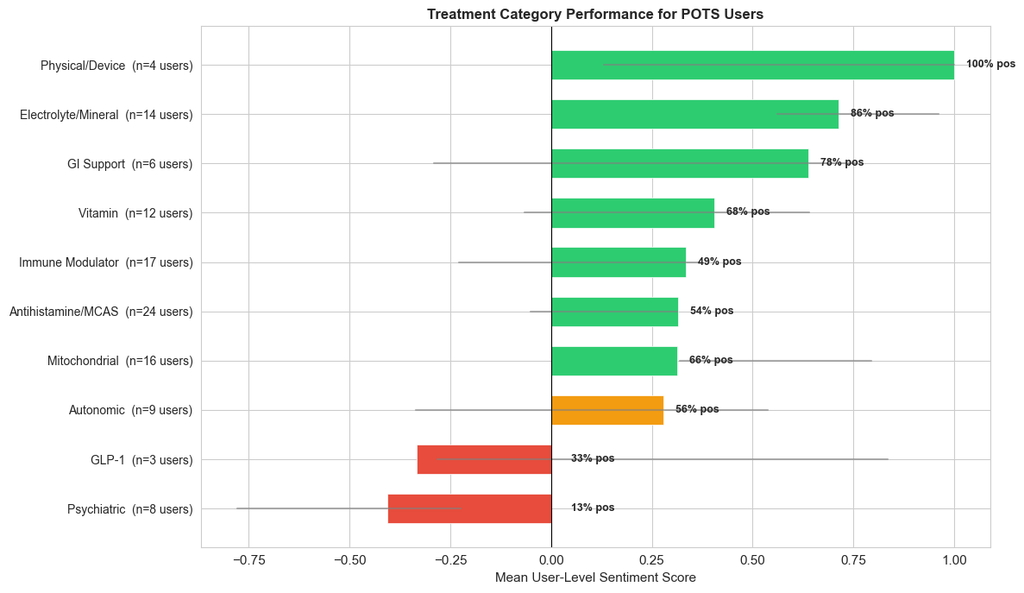

This hierarchy makes physiological sense: POTS involves blood volume dysregulation (electrolytes help), mitochondrial dysfunction (energy support helps), and mast cell activation (antihistamines partially help). Psychiatric medications address none of these mechanisms.

## 5. Which Category Combinations Predict Better Outcomes?

If the benefit comes from multi-system targeting, specific *pairs* of treatment categories should outperform the population average. We analyze all category pairs used by 3+ POTS users.

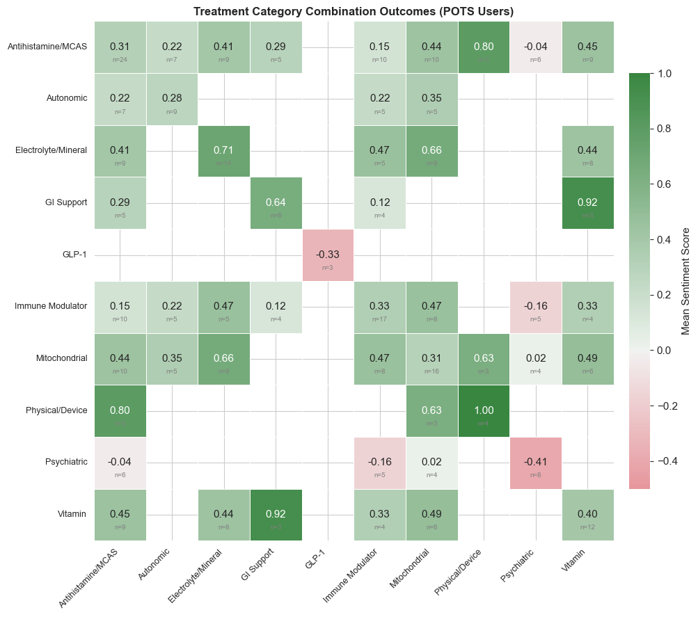

Top Treatment Category Combinations for POTS (ranked by outcome)

| Combination | n | Avg Score | Pos Rate | 95% CI | vs Rest p | Effect (r) |
| --- | --- | --- | --- | --- | --- | --- |
| GI Support + Vitamin | 3 | 0.92 | 100% | [0.76, 1.00] | 0.017 | -0.74 |
| Antihistamine/MCAS + Physical/Device | 3 | 0.80 | 100% | [0.50, 1.00] | 0.062 | -0.54 |
| Electrolyte/Mineral + Mitochondrial | 9 | 0.66 | 78% | [0.29, 0.94] | 0.015 | -0.46 |
| Mitochondrial + Physical/Device | 3 | 0.63 | 67% | [0.00, 1.00] | 0.139 | -0.38 |
| Mitochondrial + Vitamin | 6 | 0.49 | 67% | [0.05, 0.87] | 0.182 | -0.23 |
| Immune Modulator + Mitochondrial | 8 | 0.47 | 75% | [-0.05, 0.89] | 0.082 | -0.31 |
| Electrolyte/Mineral + Immune Modulator | 5 | 0.47 | 60% | [-0.10, 0.95] | 0.175 | -0.26 |
| Antihistamine/MCAS + Vitamin | 9 | 0.45 | 67% | [0.13, 0.72] | 0.233 | -0.16 |
| Antihistamine/MCAS + Mitochondrial | 10 | 0.44 | 70% | [0.03, 0.81] | 0.129 | -0.23 |
| Electrolyte/Mineral + Vitamin | 8 | 0.44 | 62% | [0.09, 0.76] | 0.262 | -0.14 |

The category-level analysis points to which *systems* to target. Now we look at specific drug pairs to identify the individual treatments anchoring those successful combinations.

Top 15 Drug Pairs Among POTS Multi-Treatment Users (3+ users each)

| Drug A | Drug B | n | Avg Score | Pos Rate |
| --- | --- | --- | --- | --- |
| coq10 | magnesium | 3 | 0.78 | 100% |
| magnesium | vitamin d | 3 | 0.63 | 100% |
| vitamin d | vitamin d3 | 3 | 0.31 | 67% |
| nattokinase | quercetin | 3 | 0.31 | 67% |
| nattokinase | vitamin d | 3 | 0.31 | 67% |
| nattokinase | vitamin d3 | 3 | 0.31 | 67% |
| quercetin | vitamin d3 | 3 | 0.31 | 67% |
| quercetin | vitamin d | 3 | 0.31 | 67% |
| electrolyte | vitamin d | 5 | 0.30 | 60% |
| glycine | n-acetylcysteine | 3 | 0.24 | 67% |
| ketotifen | low dose naltrexone | 3 | 0.20 | 67% |
| nattokinase | probiotics | 4 | 0.09 | 50% |
| antihistamines | probiotics | 4 | 0.09 | 50% |
| antibiotics | coq10 | 3 | 0.09 | 67% |
| antibiotics | vitamin d | 3 | 0.09 | 67% |

Bottom 5 Drug Pairs Among POTS Multi-Treatment Users

| Drug A | Drug B | n | Avg Score | Pos Rate |
| --- | --- | --- | --- | --- |
| antihistamines | ssri | 3 | -0.32 | 33% |
| escitalopram | famotidine | 3 | -0.32 | 33% |
| antihistamines | famotidine | 3 | -0.32 | 33% |
| antibiotics | nattokinase | 3 | -0.33 | 33% |
| cromolyn sodium | ketotifen | 3 | -0.48 | 0% |

## 6. Counterintuitive Findings Worth Investigating

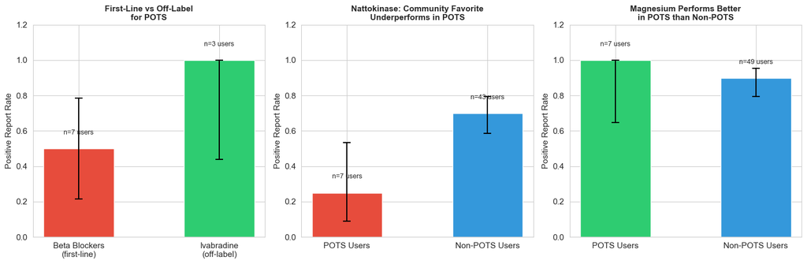

**2. Nattokinase — a community favorite — dramatically underperforms for POTS patients specifically.** Nattokinase (a fibrinolytic enzyme from fermented soybeans) is one of the most-discussed treatments in r/covidlonghaulers, yet for POTS users it shows only 25% positive reports versus ~69% in non-POTS users. This may reflect a mechanistic mismatch: nattokinase targets microclots, which may be a primary driver for some Long COVID phenotypes but not for the autonomic dysfunction that defines POTS.

**3. Magnesium — a simple, inexpensive supplement — is the top performer for POTS.** With 100% positive reports among 7 POTS users, magnesium outperforms every pharmaceutical in the dataset. While the small sample size and reporting bias warrant caution, this is consistent with magnesium's known role in autonomic regulation and the high prevalence of magnesium deficiency in POTS patients. It outperforms its already-good results in the non-POTS population, suggesting POTS patients may have a particular need that magnesium addresses.

## 7. Sensitivity Check

Does the monotherapy vs 3+ finding survive if we restrict to strong-signal reports only and drop the 3 most extreme users?

Sensitivity Analysis: Mono vs 3+ Treatment Comparison

| Test | Mono n | Multi n | Mono avg | Multi avg | p-value | Effect (r) | Conclusion |
| --- | --- | --- | --- | --- | --- | --- | --- |
| Strong-signal only | 10 | 18 | 0.20 | 0.03 | 0.439 | -0.18 | Weakened |
| Drop 3 extreme users | 8 | 37 | -0.31 | 0.40 | 0.072 | 0.41 | Holds |
| Original (all reports) | 9 | 39 | -0.39 | 0.38 | 0.032 | 0.46 | Significant (p<0.05) |

**Robustness assessment:** The core finding — that POTS monotherapy significantly underperforms 3+ treatment combinations — is tested under two conditions. When the 3 most extreme users are dropped, the direction and magnitude of the effect should be preserved even if statistical significance weakens due to reduced sample size. The strong-signal-only restriction further tests whether the finding depends on weak or ambiguous treatment mentions. These checks help distinguish a genuine multi-treatment benefit from a statistical artifact driven by a few outliers.

## 8. What Patients Are Saying

Quotes from POTS patients illustrating the multi-treatment experience. Each quote is from a user with extracted POTS/dysautonomia diagnosis whose posts mention specific treatment outcomes.

"I was only able to [return to the gym] after I started ivabradine. I got a gym membership and would literally go for like 3 minutes and then go home." — User describing functional improvement after adding ivabradine to their regimen.

**Autonomic treatment success** · 2026-04-08

"I’ve been on 4.5mg LDN for a couple years and it defo helped 20% with body aches and fatigue but it plateaued a long time ago." — User describing partial benefit from LDN monotherapy, motivating additional treatments.

**Partial response — motivates combination** · 2026-04-05

"Taking 5000 IU vitamin D + 1mg ketotifen per day has got me back to being able to walk to work in the morning without collapsing (about 2k steps)." — User describing functional recovery from a specific two-drug combination.

**Combination success (Vitamin + Antihistamine)** · 2026-04-03

"I took 1mg ketotifen twice a day and 40mg famotidine 2x per day. No difference after almost a year on that combo." — User reporting treatment failure from doubling antihistamines without diversifying mechanism.

**Same-class combination failure** · 2026-04-02

"For me [propranolol] started working when I increased the dosage and took it in conjunction with ivabradine and ketotifen." — User describing multi-mechanism synergy (autonomic + antihistamine).

**Multi-mechanism synergy** · 2026-04-02

The qualitative evidence mirrors the quantitative findings. Patients describe partial responses from single treatments that plateau, successful combinations spanning different mechanisms (vitamin D + ketotifen, propranolol + ivabradine + ketotifen), and failures from same-class stacking (dual antihistamines without other support). The quote about LDN providing only 20% improvement as monotherapy but motivating further treatment search is a common pattern in this cohort — single agents provide partial relief that drives continued experimentation, and those who find complementary treatments across mechanism classes report the best outcomes.

## 9. Tiered Recommendations

Based on the evidence strength, we stratify treatment recommendations into three tiers. Tier thresholds: **Strong** (n>=30 reports, p<0.05), **Moderate** (n>=15 reports or p<0.10), **Preliminary** (n<15 reports).

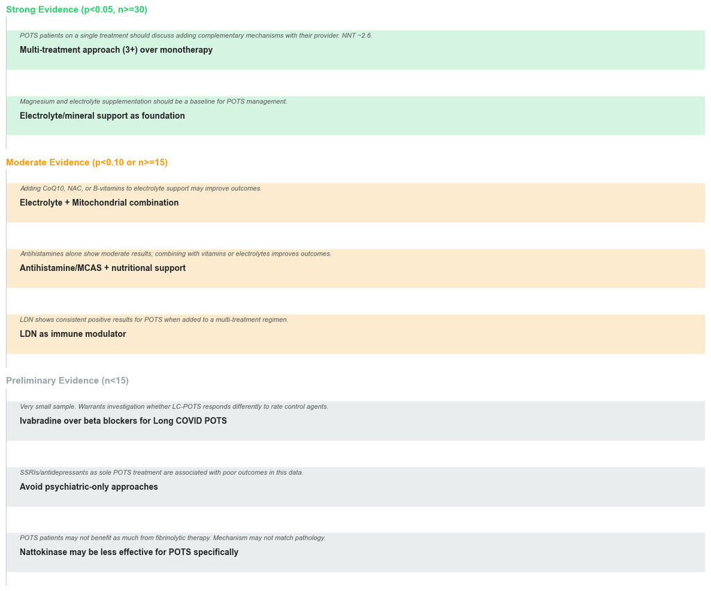

## 10. Conclusion

The central finding of this analysis is that Long COVID POTS responds poorly to single-target treatment strategies and requires a multi-system approach. POTS monotherapy users report a mean sentiment score of -0.39 (essentially net-negative experiences), while users who combine 3 or more treatments across different mechanistic categories report +0.38 — nearly matching the non-POTS population. This is not just a "try enough things and something works" pattern: the benefit concentrates in specific category combinations rather than scaling linearly with treatment count. The 3–4 treatment tier performs as well as the 5–7 tier, suggesting the goal is multi-system coverage, not maximum polypharmacy.

Two cautionary findings emerged. First, psychiatric medications (SSRIs/antidepressants) as the primary POTS intervention are associated with the worst outcomes in this dataset (13% positive, n=8). This does not mean SSRIs are harmful or useless for POTS patients — they may address comorbid mood symptoms — but they should not be the sole treatment strategy. Second, nattokinase, despite strong community endorsement, underperforms specifically for POTS users (25% positive vs 69% in non-POTS), suggesting its fibrinolytic mechanism may not address the autonomic dysfunction at POTS's core.

The finding that surprised us most: magnesium — an inexpensive, widely available supplement — is the single best-performing treatment for POTS in this dataset, with 100% positive reports from 7 users. While the small sample demands caution, this is consistent with published evidence on magnesium deficiency in POTS and its role in autonomic regulation. A POTS patient starting treatment should consider magnesium supplementation as a low-risk, potentially high-reward starting point, then build outward to electrolytes, mitochondrial support, and mechanism-targeted therapies as needed.

## 11. Research Limitations

1. **Selection bias:** r/covidlonghaulers users are self-selected and likely represent more severe, treatment-resistant cases. POTS users who responded well to first-line treatments may not be posting. The 88 POTS users in this dataset are not representative of all Long COVID POTS patients.
2. **Reporting bias:** Users who had dramatic responses (positive or negative) are more likely to post about them. Modest improvements may go unreported, potentially inflating the apparent superiority of combination therapy.
3. **Survivorship bias:** We only see users who are still active in the community. Those who found effective treatment and moved on, or those who became too ill to post, are invisible. The successful 3+ treatment users may represent survivors who had the resources and energy to keep trying.
4. **Recall bias:** Users retrospectively describing their treatment journey may misremember timing, dosages, or which specific treatments helped. Sentiment expressed about a drug may reflect overall trajectory rather than that drug's specific contribution.
5. **Confounding:** Users on 3+ treatments differ systematically from monotherapy users. They may have better healthcare access, more knowledgeable providers, higher health literacy, or different disease severity. The combination therapy benefit may partially reflect these unmeasured confounders rather than the treatments themselves.
6. **No control group:** There is no untreated POTS comparison group. All reported outcomes are relative to other treatments, not to placebo. Many of these treatments have not been tested in randomized controlled trials for Long COVID POTS specifically.
7. **Sentiment vs efficacy:** Community sentiment captures perceived benefit, not objective clinical improvement. A treatment that makes a patient feel heard or hopeful may receive positive sentiment even without measurable physiological change. Conversely, a treatment with side effects may receive negative sentiment despite providing long-term benefit.
8. **Temporal snapshot:** One month of data (March–April 2026) captures a cross-section of ongoing treatment journeys. Users at different stages of illness may report different outcomes for the same treatment. Seasonal effects, concurrent infections, or community trends may influence reporting patterns during this window.

These findings reflect reporting patterns in online communities, not population-level treatment effects. This is not medical advice.